# DATS 6101: Intro to Data Science - Mid Term Project

Team 8: Dataverse

2022-11-02

```r
# knitr::opts_chunk$set(warning = F, results = "markup", message = F)
knitr::opts_chunk$set(warning = F, results = "hide",message = F)
options(scientific=T, digits = 3)
```

```r
#Loading libraries
library(ezids)
library(ggplot2)
```

```r
car_data = data.frame(read.csv('cars.csv'))
str(car_data)
```

```
## 'data.frame':    38531 obs. of  30 variables:
##  $ manufacturer_name: chr  "Subaru" "Subaru" "Subaru" "Subaru" ...
##  $ model_name       : chr  "Outback" "Outback" "Forester" "Impreza" ...
##  $ transmission     : chr  "automatic" "automatic" "automatic" "mechanical" ...
##  $ color            : chr  "silver" "blue" "red" "blue" ...
##  $ odometer_value   : int  190000 290000 402000 10000 280000 132449 318280 350000 179000 571317 ...
##  $ year_produced    : int  2010 2002 2001 1999 2001 2011 1998 2004 2010 1999 ...
##  $ engine_fuel      : chr  "gasoline" "gasoline" "gasoline" "gasoline" ...
##  $ engine_has_gas   : chr  "False" "False" "False" "False" ...
##  $ engine_type      : chr  "gasoline" "gasoline" "gasoline" "gasoline" ...
##  $ engine_capacity  : num  2.5 3 2.5 3 2.5 2.5 2.5 2.5 2.5 2.5 ...
##  $ body_type        : chr  "universal" "universal" "suv" "sedan" ...
##  $ has_warranty     : chr  "False" "False" "False" "False" ...
##  $ state            : chr  "owned" "owned" "owned" "owned" ...
##  $ drivetrain       : chr  "all" "all" "all" "all" ...
```

[output cut: 16 more lines]

## Data cleaning

```r
car_data$transmission = as.factor(car_data$transmission)
car_data$engine_fuel = as.factor(car_data$engine_fuel)
car_data$engine_has_gas = as.factor(car_data$engine_has_gas)
car_data$engine_type = as.factor(car_data$engine_type)
car_data$body_type = as.factor(car_data$body_type)
car_data$has_warranty = as.factor(car_data$has_warranty)
car_data$state = as.factor(car_data$state)
car_data$drivetrain = as.factor(car_data$drivetrain)
car_data$is_exchangeable = as.factor(car_data$is_exchangeable)
car_data$location_region = as.factor(car_data$location_region)
```

Updating the feature as factor to make them categorical

```r
#car_data$year_produced <- strptime(car_data$year_produced, "%Y")
```

```r
feature_cols <- c(20:29)
car_data[feature_cols] <- lapply(car_data[feature_cols],factor)
str(car_data)
```

```
## 'data.frame':    38531 obs. of  30 variables:
##  $ manufacturer_name: chr  "Subaru" "Subaru" "Subaru" "Subaru" ...
##  $ model_name       : chr  "Outback" "Outback" "Forester" "Impreza" ...
##  $ transmission     : Factor w/ 2 levels "automatic","mechanical": 1 1 1 2 1 1 1 1 1 1 ...
##  $ color            : chr  "silver" "blue" "red" "blue" ...
##  $ odometer_value   : int  190000 290000 402000 10000 280000 132449 318280 350000 179000 571317 ...
##  $ year_produced    : int  2010 2002 2001 1999 2001 2011 1998 2004 2010 1999 ...
##  $ engine_fuel      : Factor w/ 6 levels "diesel","electric",..: 4 4 4 4 4 4 4 4 4 4 ...
##  $ engine_has_gas   : Factor w/ 2 levels "False","True": 1 1 1 1 1 1 1 1 1 1 ...
##  $ engine_type      : Factor w/ 3 levels "diesel","electric",..: 3 3 3 3 3 3 3 3 3 3 ...
##  $ engine_capacity  : num  2.5 3 2.5 3 2.5 2.5 2.5 2.5 2.5 2.5 ...
##  $ body_type        : Factor w/ 12 levels "cabriolet","coupe",..: 11 11 10 9 11 11 11 9 11 11 ...
##  $ has_warranty     : Factor w/ 2 levels "False","True": 1 1 1 1 1 1 1 1 1 1 ...
##  $ state            : Factor w/ 3 levels "emergency","new",..: 3 3 3 3 3 3 3 3 3 3 ...
##  $ drivetrain       : Factor w/ 3 levels "all","front",..: 1 1 1 1 1 1 1 1 1 1 ...
```

[output cut: 16 more lines]

Updating the unknown features as factor in bulk

```r
sapply(car_data, function(x) sum(is.na(x)))
```

```
## manufacturer_name        model_name      transmission             color
##                 0                 0                 0                 0
##    odometer_value     year_produced       engine_fuel    engine_has_gas
##                 0                 0                 0                 0
##       engine_type   engine_capacity         body_type      has_warranty
##                 0                10                 0                 0
##             state        drivetrain         price_usd   is_exchangeable
##                 0                 0                 0                 0
##   location_region  number_of_photos        up_counter         feature_0
##                 0                 0                 0                 0
##         feature_1         feature_2         feature_3         feature_4
##                 0                 0                 0                 0
##         feature_5         feature_6         feature_7         feature_8
##                 0                 0                 0                 0
##         feature_9   duration_listed
##                 0                 0
```

Getting some null values in engine capacity

```r
car_data$engine_capacity[is.na(car_data$engine_capacity)] <- mean(car_data$engine_capacity,na.rm = TRUE)
sapply(car_data, function(x) sum(is.na(x)))
```

```
## manufacturer_name        model_name      transmission             color
##                 0                 0                 0                 0
##    odometer_value     year_produced       engine_fuel    engine_has_gas
##                 0                 0                 0                 0
##       engine_type   engine_capacity         body_type      has_warranty
##                 0                 0                 0                 0
##             state        drivetrain         price_usd   is_exchangeable
##                 0                 0                 0                 0
##   location_region  number_of_photos        up_counter         feature_0
##                 0                 0                 0                 0
##         feature_1         feature_2         feature_3         feature_4
##                 0                 0                 0                 0
##         feature_5         feature_6         feature_7         feature_8
##                 0                 0                 0                 0
##         feature_9   duration_listed
##                 0                 0
```

Replaced 10 missing values for engline capacity with mean of rest of the values

```r
# car_data = outlierKD2(car_data, odometer_value, TRUE, TRUE, TRUE, TRUE)
# odometer_value_na = sum(is.na(car_data$odometer_value))
# print(odometer_value_na)
```

There might be the possibility that vehicle is used for longer time

## Exploratory data analysis

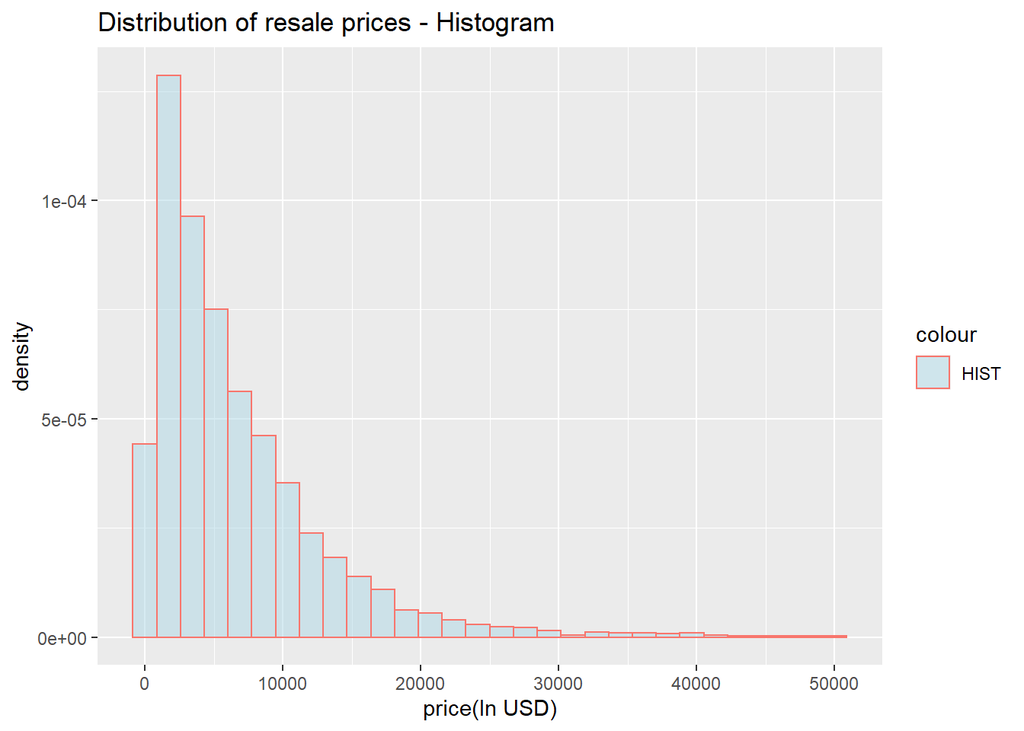

```r
p <- ggplot(car_data, aes(x = price_usd)) +
     geom_histogram(aes(y = stat(density), colour = "HIST"), fill="light blue", bins=30, alpha=.5) +
      labs(x = 'price(In USD)') + labs(title = 'Distribution of resale prices - Histogram')
p
```

## Price destribution

Transmission feature

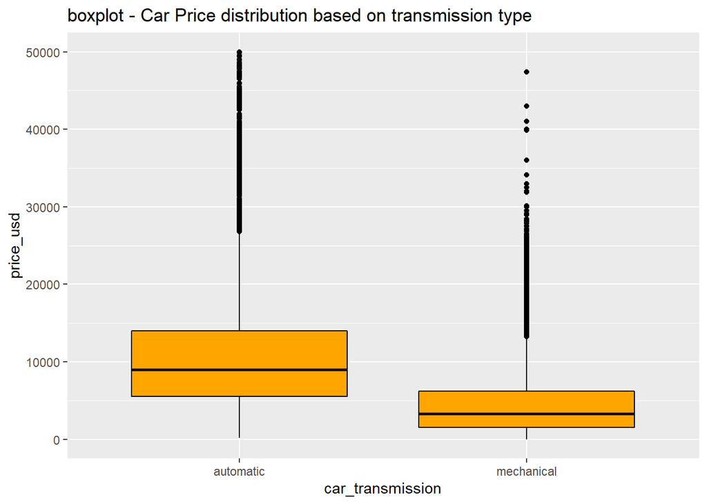

```r
plot1 <- ggplot(car_data, aes(x=transmission, y=price_usd)) +
  geom_boxplot(color="black", fill="orange")+
  labs(x="car_transmission",y="price_usd") + labs(title="boxplot - Car Price distribution based on transmission type")
plot1
```

## odometer_value

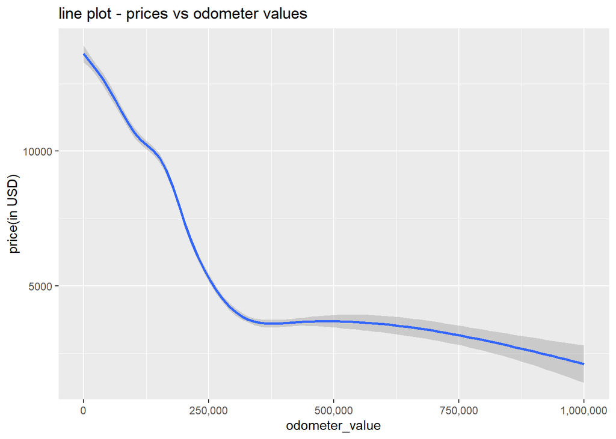

```r
ggplot(data = car_data) +
    geom_smooth(mapping = aes(x = odometer_value, y = price_usd)) +
    scale_x_continuous(name="odometer_value", labels = scales::comma) +
        labs(x = 'odometer_value', y = 'price(in USD)') + labs(title = 'line plot - prices vs odometer values')
```

We can clearly see that as odometer value is increasing, car prices are going down.

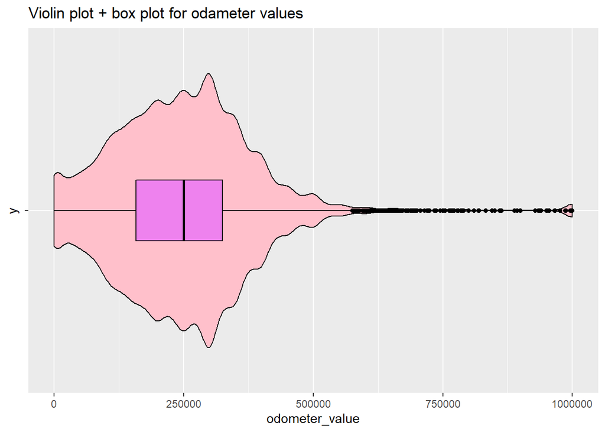

```r
plot3 <- ggplot(car_data,aes(x = odometer_value,y = '',color = odometer_value)) +
        geom_violin(color="black", fill="pink") + geom_boxplot(width = .2,color="black", fill="violet") +
        labs(x = 'odometer_value') + labs(title = 'Violin plot + box plot for odameter values')
plot3
```

violin plot, checking odometer distribution and box plot in the same graph.

Scatter plot with fitting line

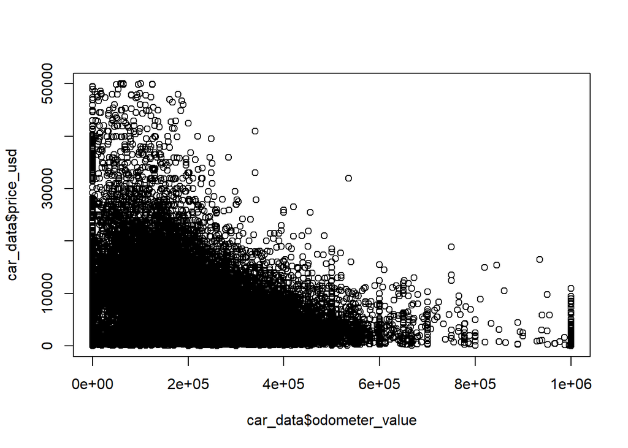

```r
plot(car_data$odometer_value, car_data$price_usd)
```

```r
updated_data = outlierKD2(car_data, odometer_value, TRUE, TRUE, TRUE, TRUE)
```

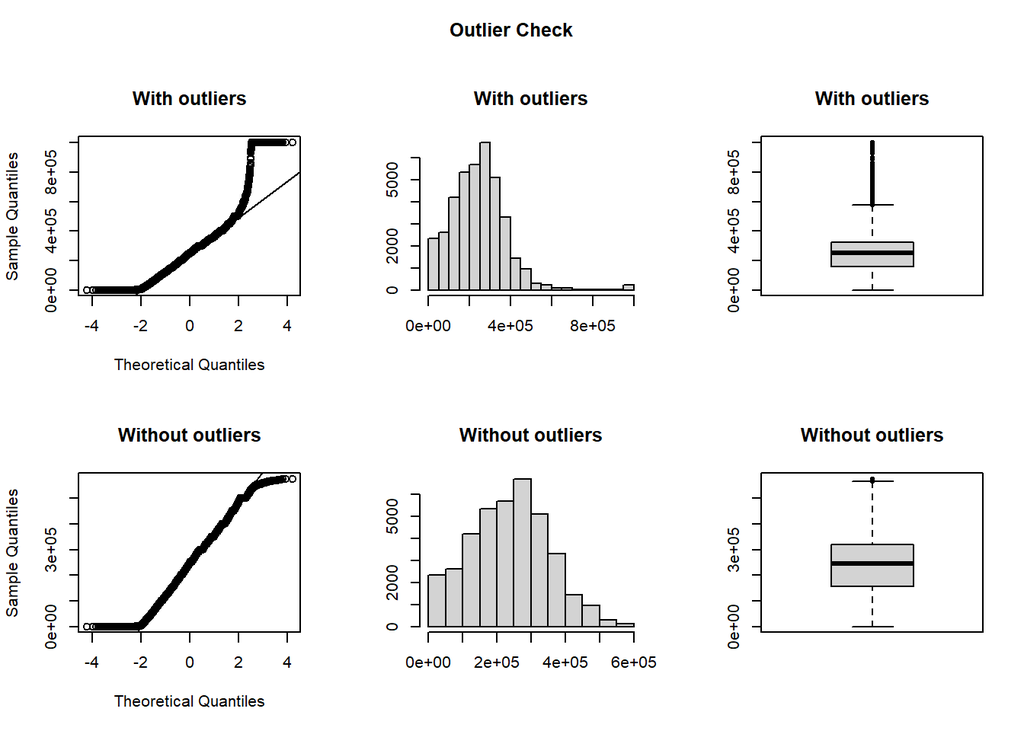

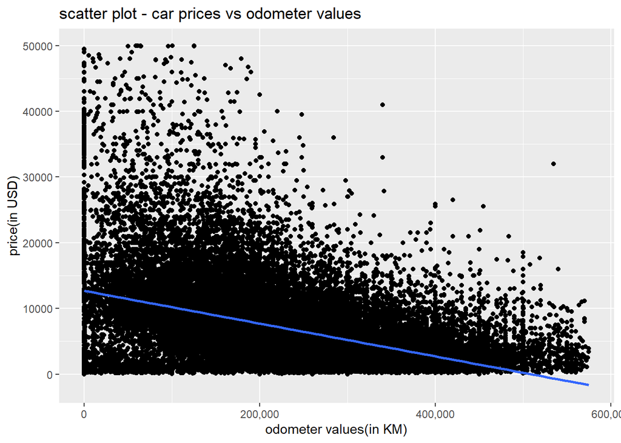

```r
ggplot(updated_data, aes(x=odometer_value, y=price_usd)) +
   geom_point()+
   geom_smooth(method=lm) +
   labs(title = 'scatter plot - car prices vs odometer values') +
   labs(x = 'odometer values(in KM)', y = 'price(in USD)') + scale_x_continuous(name='odometer values(in KM)', labels = scales::comma)
```

By removing outliers from odometer value, we are getting good relation for price vs odometer value.

## year_produced

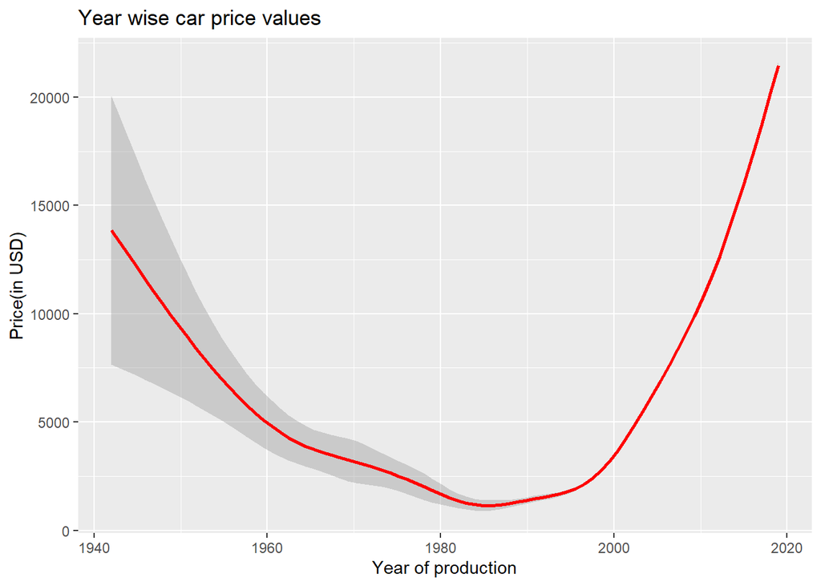

```r
ggplot(data = car_data) +
    geom_smooth(color = 'red',mapping = aes(x = year_produced, y = price_usd)) + labs(x = 'Year of production', y = 'Price(in USD)') +
    labs(title ='Year wise car price values')
```

As we can see that car prices of vintage cars is high. Also the resell price is high for latest cars.

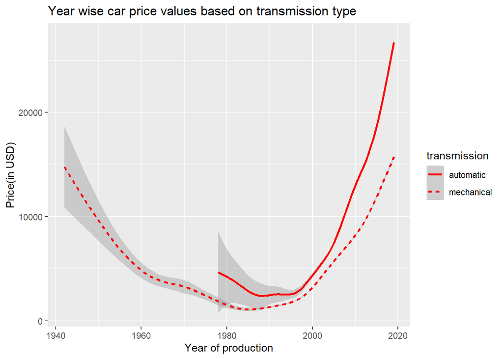

```r
plot_transmission <- ggplot(data = car_data) +
    geom_smooth(color = 'red',mapping = aes(x = year_produced, y = price_usd,linetype = transmission)) +
    labs(title = 'Year wise car price values based on transmission type') + labs(x = 'Year of production', y = 'Price(in USD)')
plot_transmission
```

To check the Vintage category, mechanical are categorize as vintage and automatic cars are available from 1978. We are getting the similar results compared to the previous plot based on complete data.

## Engine fuel

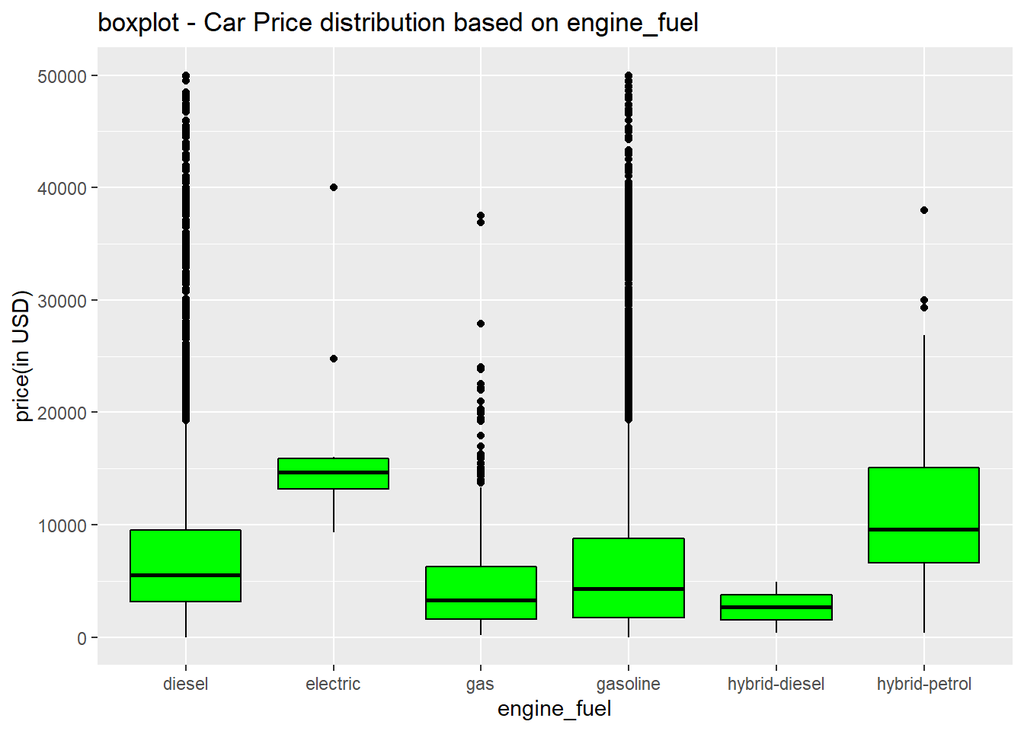

```r
plot1 <- ggplot(car_data, aes(x=engine_fuel, y=price_usd)) +
  geom_boxplot(color="black", fill="green")+
  labs(x="engine_fuel",y="price(in USD)") + labs(title="boxplot - Car Price distribution based on engine_fuel")
plot1
```

## car prices based on engine cost

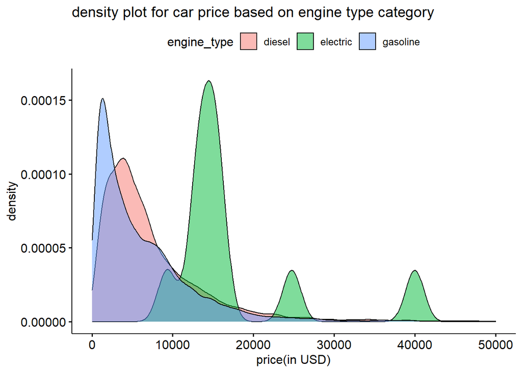

```r
library(ggpubr)
xplot <- ggdensity(car_data, "price_usd", fill = "engine_type",
                   palette = "arc") + labs(title = 'density plot for car price based on engine type category') + labs(x = 'price(in USD)')
xplot
```

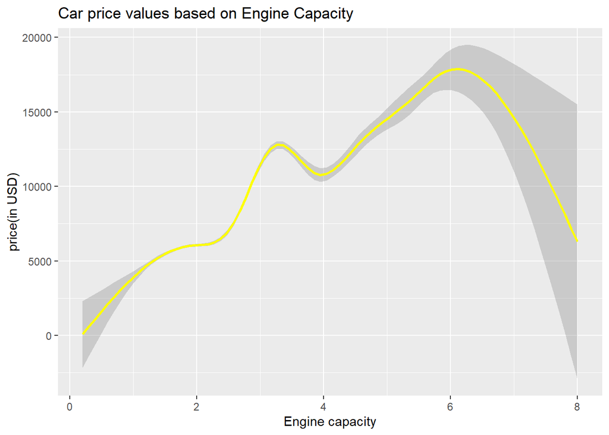

```r
ggplot(data = car_data, aes(x = engine_capacity, y = price_usd)) +
    geom_smooth(color = 'yellow') +
    labs(title = 'Car price values based on Engine Capacity') + labs(x = 'Engine capacity', y = 'price(in USD)')
```

## has warranty feature

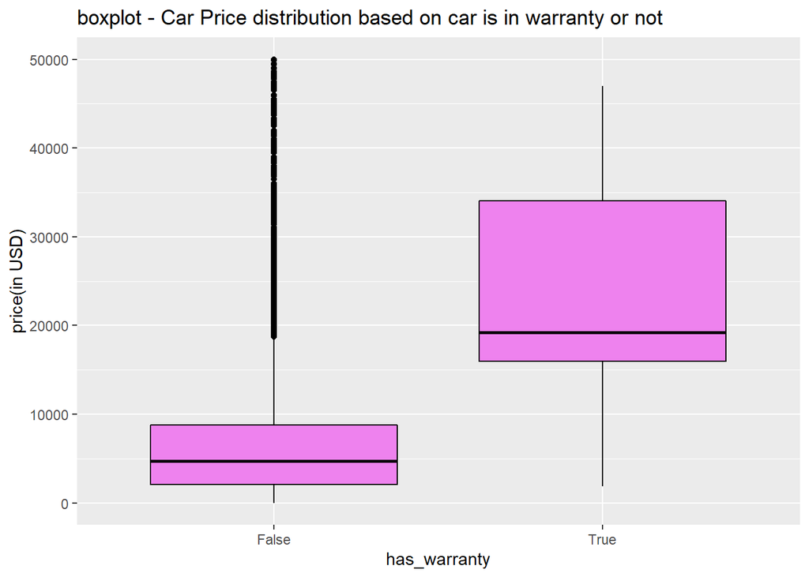

```r
plot_warranty <- ggplot(car_data, aes(x=has_warranty, y=price_usd)) +
  geom_boxplot(color="black", fill="violet")+
  labs(x="has_warranty",y="price(in USD)") + labs(title="boxplot - Car Price distribution based on car is in warranty or not")
plot_warranty
```

As we can see, cars which are in warranty have the better resell prices than the cars which are not covered under warranty. Also we can see so many outliers in ‘no warranty’ categories. That pool is belongs to the vintage cars where prices are high but the car is not in the warranty.